# Exploring Data: **Full Scripts**

Scripts are [text files](https://en.wikipedia.org/wiki/Text_file) which contain executable commands. Python scripts are saved as text files with the extension `.py`. When programs become complex, it can become more convenient to store them in one or more scripts.

In the folder in which this notebook is saved, you will find two scripts called **script1_parse.py** and **script2_analyse.py**. These two scripts implement the key functionality and analyses from the previous notebooks in this Lesson.

⭐ It is **almost always best** to separate your code into **parsing** and **analysis**. You can do this using separate scripts, as discussed in this notebook, or you can do this using separate notebooks, as demonstrated in earlier notebooks from this lesson.

If you choose to save your code in Python scripts, note that they can be executed from a Jupyter notebook using the `%run` command, like this:

```python
%run script1_parse.py
```

```
parsed_data.csv successfully written.
```

The `%run` command has executed **all** commands in the script. If you look at the details of the script you will see that it parses all five HTML pages, then saves the results in a CSV file, which you will find written in the directory in which this notebook is saved.

Let's run the next script:

```
Central tendency measures:
    Mean        =  3687.17
    Median      =  2667.0
    Mode        =  [5374]

Dispersion measures:
    Minimum              =  269
    Maximum              =  18498
    Range                =  18229
    25th percentile      =  1797.5
    75th percentile      =  5094.0
    Inter-quartile range =  3296.5
    Variance             =  8080831.351100006
    Standard deviation   =  2842.6803110972583

Non-normality measures:
    Skewness     = 1.9431730084032617
    Kurtosis     = 5.371752531923347
```

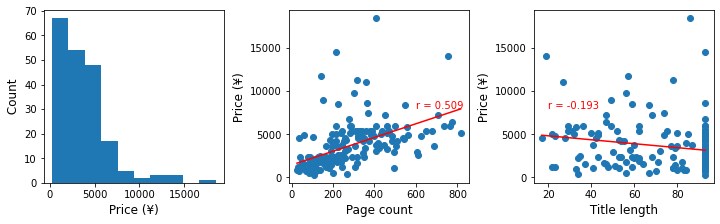

```python
%run script2_analyse.py
```

The figure above was generated by the commands in the script, and Jupyter has automatically embedded the figure in this notebook.

⭐ Note that, after running a script using the `%run` command, all of the script's variables are available to use in this notebook. For example:

```python
print( price )
```

```
0       1075
1       1790
2       2379
3       2364
4        960
       ...
195      989
196      838
197     3698
198      956
199    14047
Name: Price, Length: 200, dtype: int64
```

The variable `price` is specified in **script2_analyse.py**, and is now available for use in this notebook.

Also note that functions defined in scripts are also available for use in this notebook. For example, we could use the `parse_page` function that is defined in **script1_parse.py** like this:

```python
dir0      = os.path.abspath('')                  # directory in which this notebook is saved
fnameHTML = os.path.join(dirData, 'page1.html')  # an HTML data file
a,b,c     = parse_page( fnameHTML )              # parse results (title, pages, price)

print(c)
```

```
[1075, 1790, 2379, 2364, 960, 1219, 8491, 3205, 4729, 3033, 2352, 1581, 1801, 5374, 4325, 4526, 7192, 14542, 960, 834, 5388, 2385, 5136, 5408, 5374, 1076, 11060, 5900, 2567, 5152, 5374, 5374, 2153, 4531, 836, 4182, 1089, 1766, 5981, 4194]
```

### Summary

To keep your notebooks concise, it can sometimes be convenient to save complex or long sequences of commands in scripts (i.e., `.py` files), and to use the `%run` command to call the script.

This approach hides the Python code details from the notebook reader, and allows them to focus on bigger issues, like the results of analysis.

Using scripts vs. using notebooks is your choice as a data analyst. If you are preparing Python code for yourself, either is fine. If you are preparing Python code for your boss, for a customer, or as a course project submission, it is usually best to hide the Python code details in scripts, so that the reader can focus on the main findings.